# SPPH 504 Section 007 Lab 9: Regression with categorical vs. survival outcomes: Part 4 (Survival analysis)

Ehsan Karim, ehsan.karim@ubc.ca

01 May 2020

# 1 The lung dataset

- inst: Institution code
- time: Survival time in days
- status: censoring status
  - 1=censored,
  - 2=dead
- age: Age in years
- sex:
  - Male=1
  - Female=2
- ph.ecog: ECOG performance score (0=good 5=dead)
- ph.karno: Karnofsky performance score (bad=0-good=100) rated by physician
- pat.karno: Karnofsky performance score as rated by patient
- meal.cal: Calories consumed at meals
- wt.loss: Weight loss in last six months

```r
library(survival)
head(lung)
```

```
##   inst time status age sex ph.ecog ph.karno pat.karno meal.cal wt.loss
## 1    3  306      2  74   1       1       90       100     1175      NA
## 2    3  455      2  68   1       0       90        90     1225      15
## 3    3 1010      1  56   1       0       90        90       NA      15
## 4    5  210      2  57   1       1       90        60     1150      11
## 5    1  883      2  60   1       0      100        90       NA       0
## 6   12 1022      1  74   1       1       50        80      513       0
```

```r
kable(head(lung))
```

| inst | time | status | age | sex | ph.ecog | ph.karno | pat.karno | meal.cal | wt.loss |
| --- | --- | --- | --- | --- | --- | --- | --- | --- | --- |
| 3 | 306 | 2 | 74 | 1 | 1 | 90 | 100 | 1175 | NA |
| 3 | 455 | 2 | 68 | 1 | 0 | 90 | 90 | 1225 | 15 |
| 3 | 1010 | 1 | 56 | 1 | 0 | 90 | 90 | NA | 15 |
| 5 | 210 | 2 | 57 | 1 | 1 | 90 | 60 | 1150 | 11 |
| 1 | 883 | 2 | 60 | 1 | 0 | 100 | 90 | NA | 0 |
| 12 | 1022 | 1 | 74 | 1 | 1 | 50 | 80 | 513 | 0 |

```r
# kable(lung)
```

# 2 What is censoring?

Censoring occurs if a subject leave the study without experiencing the event

# 3 Types of censoring

## 3.1 Left censoring:

The subject has experienced the event before enrollment

## 3.2 Right censoring:

- Loss to follow-up
- Withdraw from the study
- Survive to the end of the study

In this lab, we focus on right censoring

# 4 Components of survival data

There are four components in survival data:

For any individual i:

- Event time $T_i$
- Censoring time $C_i$
- Event indicator $\delta_i$
- Observed time $Y_i=min(T_i,C_i)$

# 5 Event indicator

The event indicator $\delta_i$ was defined as a binary data

- $\delta_i=1$ if $T_i \leq C_i$
- $\delta_i=0$ if $T_i > C_i$

# 6 Survival function

Survival function represents the probability that an individual will survival past time $t$

$S(t) = Pr(T>t)=1-F(t)$, where $F(t)$ is the cumulative distribution function.

# 7 Survival probability

Given that a subject is still alive just before time $t$, the survival probability $S(t)$ represents the probability of surviving beyond time $t$. We could plot survival probability in lung dataset

# 8 Creating survival objects

A survival object is the survival time and can be used as the “response” in survival analysis. To estimate $S(t)$, we usually use the non-parametric method called Kaplan-Meier method. In R, we can use “Surv” in survival package to create survival objects. Let us take a look at the first 10 subjects in lung dataset. The numbers are the survival time for each individual, $+$ indicates that the observation has been censored

```r
Surv(lung$time, lung$status)[1:10]
```

```
##  [1]  306   455  1010+  210   883  1022+  310   361   218   166
```

# 9 Estimating survival curves with the Kaplan-Meier method

“survfit” in survival package can help us to estimate survival curves using KM method

```r
f1 <- survfit(Surv(time, status) ~ 1, data = lung)
# Surv(time, status) is the survival object we just introduced
# show the objects in the f1
names(f1)
```

```
##  [1] "n"         "time"      "n.risk"    "n.event"   "n.censor"  "surv"
##  [7] "std.err"   "cumhaz"    "std.chaz"  "type"      "logse"     "conf.int"
## [13] "conf.type" "lower"     "upper"     "call"
```

# 10 Kaplan-Meier plot

We could plot the above fitting to have a KM plot in R

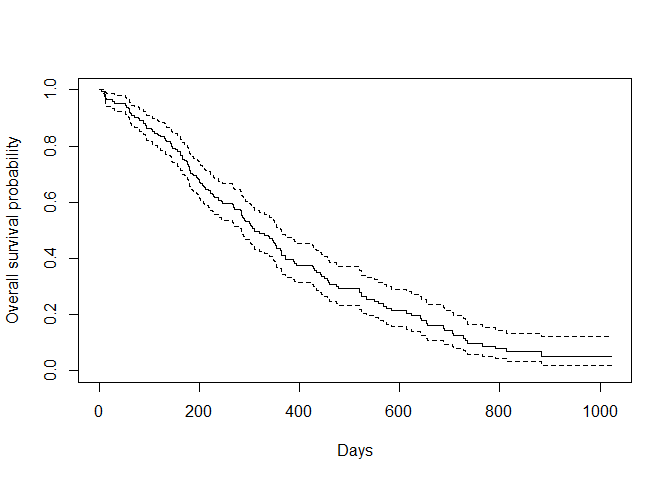

```r
plot(survfit(Surv(time, status) ~ 1, data = lung),
     xlab = "Days",
     ylab = "Overall survival probability")
```

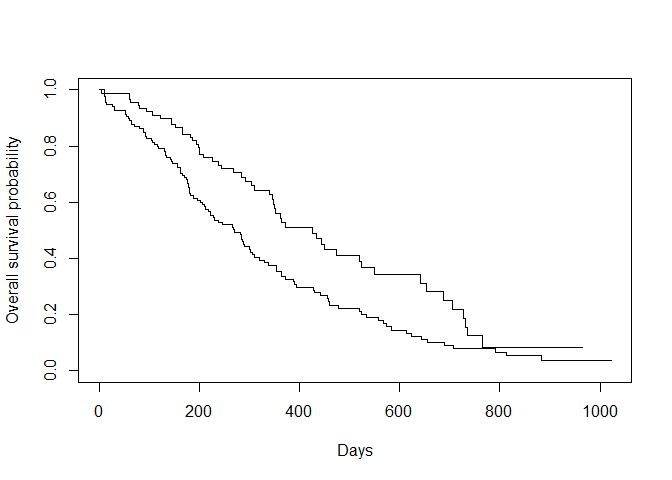

```r
## We could also do KM by groups
plot(survfit(Surv(time, status) ~ sex, data = lung),
     xlab = "Days",
     ylab = "Overall survival probability")
```

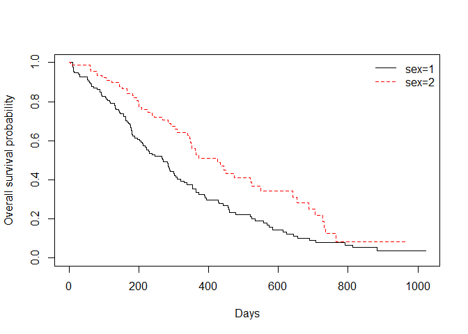

```r
## Adding legend
fit0 <- survfit(Surv(time, status) ~ sex, data = lung)
plot(fit0,
     xlab = "Days",
     ylab = "Overall survival probability",
     lty = 1:2,col=1:2)
Lab.x <- names(fit0$strata)
legend("topright", legend=Lab.x,
  col=1:2, lty=1:2,horiz=FALSE,bty='n')
```

```r
#library(survminer)
# ggsurvplot(survfit(Surv(time, status) ~ sex, data = lung), data = lung,
#            xlab="Days",
#            ylab = "Survival probability")
```

# 11 Estimating median survival time

Usually, the survival time will not be normally (or symmetrically) distributed. Therefore, mean is not a good summary for survival time. Instead, we use median to estimate. “survfit” in survival package present the summary of median

```r
survfit(Surv(time, status) ~ 1, data = lung)
```

```
## Call: survfit(formula = Surv(time, status) ~ 1, data = lung)
##
##       n  events  median 0.95LCL 0.95UCL
##     228     165     310     285     363
```

# 12 Comparing survival times between groups

We could use log-rank test to test whether there exists significant difference in survival time between groups. The log-rank test put the same weights on every observation. It could be done in R use “survdiff” from survival package

```r
survdiff(Surv(time, status) ~ sex, data = lung)
```

```
## Call:
## survdiff(formula = Surv(time, status) ~ sex, data = lung)
##
##         N Observed Expected (O-E)^2/E (O-E)^2/V
## sex=1 138      112     91.6      4.55      10.3
## sex=2  90       53     73.4      5.68      10.3
##
##  Chisq= 10.3  on 1 degrees of freedom, p= 0.001
```

The results indicated that the survival time depends on the sex (p-value = 0.001); e.g., associated with sex variable.

# 13 The Cox regression model

The Cox regression model (aka Cox proportional-hazard model) is semi-parametric model to quantify the effect size in survival analysis.

- $h(t|X_i)=h_0(t)exp(\beta_0+\beta_1X_{i1}+\beta_2X_{i2}+\beta_3X_{i3}+...+\beta_pX_{ip})$, where
  - $h_0(t)$ is the baseline hazard and
  - $h(t)$ is the hazard at time $t$

In R, we have “coxph” from survival package to fit a Cox PH model

```r
fit <- coxph(Surv(time, status) ~ sex, data = lung) # add sex as covariate
summary(fit)
```

```
## Call:
## coxph(formula = Surv(time, status) ~ sex, data = lung)
##
##   n= 228, number of events= 165
##
##        coef exp(coef) se(coef)      z Pr(>|z|)
## sex -0.5310    0.5880   0.1672 -3.176  0.00149 **
## ---
## Signif. codes:  0 '***' 0.001 '**' 0.01 '*' 0.05 '.' 0.1 ' ' 1
##
##     exp(coef) exp(-coef) lower .95 upper .95
## sex     0.588      1.701    0.4237     0.816
##
## Concordance= 0.579  (se = 0.021 )
## Likelihood ratio test= 10.63  on 1 df,   p=0.001
## Wald test            = 10.09  on 1 df,   p=0.001
## Score (logrank) test = 10.33  on 1 df,   p=0.001
```

```r
require(Publish)
publish(fit)
```

```
##  Variable Units HazardRatio       CI.95   p-value
##       sex              0.59 [0.42;0.82]   0.00149
```

More variables

```r
fit <- coxph(Surv(time, status) ~ sex + ph.ecog +
               ph.karno + pat.karno + meal.cal + wt.loss,
             data = lung) # add more covariates
summary(fit)
```

```
## Call:
## coxph(formula = Surv(time, status) ~ sex + ph.ecog + ph.karno +
##     pat.karno + meal.cal + wt.loss, data = lung)
##
##   n= 168, number of events= 121
##    (60 observations deleted due to missingness)
##
##                 coef  exp(coef)   se(coef)      z Pr(>|z|)
## sex       -5.571e-01  5.729e-01  2.003e-01 -2.782  0.00541 **
## ph.ecog    7.377e-01  2.091e+00  2.260e-01  3.264  0.00110 **
## ph.karno   2.041e-02  1.021e+00  1.108e-02  1.842  0.06549 .
## pat.karno -1.263e-02  9.874e-01  8.062e-03 -1.567  0.11707
## meal.cal  -8.303e-06  1.000e+00  2.567e-04 -0.032  0.97420
## wt.loss   -1.460e-02  9.855e-01  7.708e-03 -1.894  0.05820 .
## ---
## Signif. codes:  0 '***' 0.001 '**' 0.01 '*' 0.05 '.' 0.1 ' ' 1
##
##           exp(coef) exp(-coef) lower .95 upper .95
## sex          0.5729     1.7456    0.3869    0.8483
## ph.ecog      2.0910     0.4782    1.3427    3.2565
## ph.karno     1.0206     0.9798    0.9987    1.0430
## pat.karno    0.9874     1.0127    0.9720    1.0032
## meal.cal     1.0000     1.0000    0.9995    1.0005
## wt.loss      0.9855     1.0147    0.9707    1.0005
##
## Concordance= 0.656  (se = 0.029 )
## Likelihood ratio test= 27.47  on 6 df,   p=1e-04
## Wald test            = 27.02  on 6 df,   p=1e-04
## Score (logrank) test = 27.82  on 6 df,   p=1e-04
```

# 14 Formatting Cox regression results

To format the Cox regression results into a nice table format, we could use “tidy” (broom package).

```r
library(broom)
library(tidyverse)
summary(fit)
```

```
## Call:
## coxph(formula = Surv(time, status) ~ sex + ph.ecog + ph.karno +
##     pat.karno + meal.cal + wt.loss, data = lung)
##
##   n= 168, number of events= 121
##    (60 observations deleted due to missingness)
##
##                 coef  exp(coef)   se(coef)      z Pr(>|z|)
## sex       -5.571e-01  5.729e-01  2.003e-01 -2.782  0.00541 **
## ph.ecog    7.377e-01  2.091e+00  2.260e-01  3.264  0.00110 **
## ph.karno   2.041e-02  1.021e+00  1.108e-02  1.842  0.06549 .
## pat.karno -1.263e-02  9.874e-01  8.062e-03 -1.567  0.11707
## meal.cal  -8.303e-06  1.000e+00  2.567e-04 -0.032  0.97420
## wt.loss   -1.460e-02  9.855e-01  7.708e-03 -1.894  0.05820 .
## ---
## Signif. codes:  0 '***' 0.001 '**' 0.01 '*' 0.05 '.' 0.1 ' ' 1
##
##           exp(coef) exp(-coef) lower .95 upper .95
## sex          0.5729     1.7456    0.3869    0.8483
## ph.ecog      2.0910     0.4782    1.3427    3.2565
## ph.karno     1.0206     0.9798    0.9987    1.0430
## pat.karno    0.9874     1.0127    0.9720    1.0032
## meal.cal     1.0000     1.0000    0.9995    1.0005
## wt.loss      0.9855     1.0147    0.9707    1.0005
##
## Concordance= 0.656  (se = 0.029 )
## Likelihood ratio test= 27.47  on 6 df,   p=1e-04
## Wald test            = 27.02  on 6 df,   p=1e-04
## Score (logrank) test = 27.82  on 6 df,   p=1e-04
```

```r
require(Publish)
publish(fit)
```

```
##   Variable Units Missing HazardRatio       CI.95   p-value
##        sex             0        0.57 [0.39;0.85]   0.00541
##    ph.ecog             1        2.09 [1.34;3.26]   0.00110
##   ph.karno             1        1.02 [1.00;1.04]   0.06549
##  pat.karno             3        0.99 [0.97;1.00]   0.11707
##   meal.cal            47        1.00 [1.00;1.00]   0.97420
##    wt.loss            14        0.99 [0.97;1.00]   0.05820
```

```r
kable(broom::tidy(fit, exp = TRUE))
```

| term | estimate | std.error | statistic | p.value | conf.low | conf.high |
| --- | --- | --- | --- | --- | --- | --- |
| sex | 0.5728725 | 0.2002798 | -2.7815687 | 0.0054097 | 0.3868829 | 0.8482746 |
| ph.ecog | 2.0910352 | 0.2260265 | 3.2635959 | 0.0011001 | 1.3426636 | 3.2565330 |
| ph.karno | 1.0206185 | 0.0110803 | 1.8418903 | 0.0654912 | 0.9986926 | 1.0430258 |
| pat.karno | 0.9874450 | 0.0080618 | -1.5672047 | 0.1170668 | 0.9719652 | 1.0031714 |
| meal.cal | 0.9999917 | 0.0002567 | -0.0323431 | 0.9741984 | 0.9994887 | 1.0004950 |
| wt.loss | 0.9855065 | 0.0077076 | -1.8941781 | 0.0582014 | 0.9707307 | 1.0005072 |

```r
kable(broom::tidy(fit, exp = TRUE), digits = 2)
```

| term | estimate | std.error | statistic | p.value | conf.low | conf.high |
| --- | --- | --- | --- | --- | --- | --- |
| sex | 0.57 | 0.20 | -2.78 | 0.01 | 0.39 | 0.85 |
| ph.ecog | 2.09 | 0.23 | 3.26 | 0.00 | 1.34 | 3.26 |
| ph.karno | 1.02 | 0.01 | 1.84 | 0.07 | 1.00 | 1.04 |
| pat.karno | 0.99 | 0.01 | -1.57 | 0.12 | 0.97 | 1.00 |
| meal.cal | 1.00 | 0.00 | -0.03 | 0.97 | 1.00 | 1.00 |
| wt.loss | 0.99 | 0.01 | -1.89 | 0.06 | 0.97 | 1.00 |

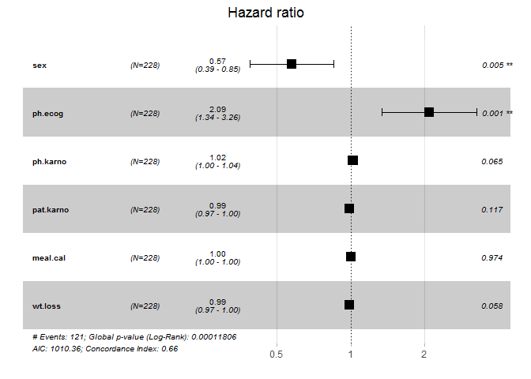

```r
require(survminer)
ggforest(fit, data = lung)
```

# 15 Hazard ratios

- In Cox regression model, the quantity we interested is the **hazard ratio**, which is the ratio of hazards in two different groups (i.e., exposed vs unexposed).
- Hazard ratio at time $t$ is denoted by $HR=\frac{h_1(t)}{h_0(t)}$ where $h(t)$ is the hazard function representing the instantaneous rate that the first event may occur.
- Hazard ratio is **not** a risk, and it can estimated by exponatial the estimated coefficients (i.e., $exp(\beta)$).
- In the above Cox model, the HR is 0.59 which indicated that the hazard in Female is smaller than Male.
- In generally, a $HR>1$ indicates a higher hazard, and $HR<1$ indicated a reduced hazard.

# 16 Assessing proportional hazards

- As mentioned before, the Cox model is also called as Cox proportional hazard model.
- The assumption made here is the hazards in both group are proportional.
- The easiest way of assessing proportional hazard assumption is to use “cox.zph”
- This function uses the Schoenfeld residuals against the transformed time.
- Ideally, this checks if the hazard rate of an individual is relatively constant in time.

```r
f2 <- coxph(Surv(time, status) ~ sex, data = lung)
test <- cox.zph(f2)
test
```

```
##        chisq df     p
## sex     2.86  1 0.091
## GLOBAL  2.86  1 0.091
```

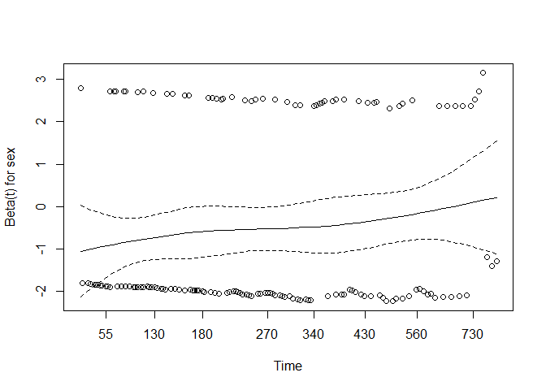

```r
plot(test)
```

- Here, p-value is greater than 0.05, there is no evidence against PH assumption.
- Having very small p values (say, 0.001) indicates that there may be time dependent coefficients which the modelling needs to take care of.

# 17 Time-dependent covariate

Time-dependent covariate occurs when individual’s covariate values are may be different at different time (measured repeatedly over time).

## 17.1 Data setup

```r
# Create a simple data set for a time-dependent model
# See ?coxph
test.data <- list(start=c(1, 2, 5, 2, 1, 7, 3, 4, 8, 8),
                  stop =c(2, 3, 6, 7, 8, 9, 9, 9,14,17),
                  event=c(1, 1, 1, 1, 1, 1, 1, 0, 0, 0),
                  tx  =c(1, 0, 0, 1, 0, 1, 1, 1, 0, 0) )
test.data
```

```
## $start
##  [1] 1 2 5 2 1 7 3 4 8 8
##
## $stop
##  [1]  2  3  6  7  8  9  9  9 14 17
##
## $event
##  [1] 1 1 1 1 1 1 1 0 0 0
##
## $tx
##  [1] 1 0 0 1 0 1 1 1 0 0
```

```r
as.data.frame(test.data)
```

```
##    start stop event tx
## 1      1    2     1  1
## 2      2    3     1  0
## 3      5    6     1  0
## 4      2    7     1  1
## 5      1    8     1  0
## 6      7    9     1  1
## 7      3    9     1  1
## 8      4    9     0  1
## 9      8   14     0  0
## 10     8   17     0  0
```

# 18 Time-dependent covariate - Cox regression

```r
fit.td <- coxph( Surv(start, stop, event) ~ tx, test.data)
summary(fit.td)
```

```
## Call:
## coxph(formula = Surv(start, stop, event) ~ tx, data = test.data)
##
##   n= 10, number of events= 7
##
##        coef exp(coef) se(coef)      z Pr(>|z|)
## tx -0.02111   0.97912  0.79518 -0.027    0.979
##
##    exp(coef) exp(-coef) lower .95 upper .95
## tx    0.9791      1.021    0.2061     4.653
##
## Concordance= 0.526  (se = 0.129 )
## Likelihood ratio test= 0  on 1 df,   p=1
## Wald test            = 0  on 1 df,   p=1
## Score (logrank) test = 0  on 1 df,   p=1
```

```r
publish(fit.td)
```

```
##  Variable Units HazardRatio       CI.95 p-value
##        tx              0.98 [0.21;4.65]   0.979
```